# Data Science Project (Time Series)

[output not shown]

[output cut: 33 more lines]

[output not shown]

[output not shown]

[output not shown]

[output cut: 40 more lines]

[output not shown]

[output not shown]

[output not shown]

[output cut: 38 more lines]

[output not shown]

[output not shown]

[output not shown]

[output cut: 37 more lines]

[output not shown]

[output not shown]

[output not shown]

[output cut: 43 more lines]

[output not shown]

[output not shown]

[output not shown]

[output cut: 41 more lines]

[output not shown]

[output not shown]

[output not shown]

[output cut: 49 more lines]

[output not shown]

[output not shown]

[output not shown]

[output cut: 47 more lines]

[output not shown]

[output not shown]

[output not shown]

[output cut: 53 more lines]

[output not shown]

[output not shown]

[output not shown]

[output cut: 52 more lines]

[output not shown]

[output not shown]

[output not shown]

[output cut: 50 more lines]

[output not shown]

[output not shown]

[output not shown]

[output cut: 55 more lines]

[output not shown]

[output not shown]

[output not shown]

[output cut: 63 more lines]

[output not shown]

[output not shown]

[output not shown]

[output cut: 55 more lines]

[output not shown]

[output not shown]

[output not shown]

[output cut: 64 more lines]

[output not shown]

[output not shown]

[output not shown]

[output cut: 62 more lines]

[output not shown]

[output not shown]

[output not shown]

[output cut: 67 more lines]

[output not shown]

[output not shown]

[output not shown]

[output cut: 71 more lines]

[output not shown]

[output not shown]

```
Лучшее значение MSE: 25.772694
Оптимальные значения гиперпараметров: {'max_depth': 16, 'n_estimators': 96}
```

Лучшего значения RMSE в размере 25.77 заказов RandomForest достигает при количестве деревьев, равному 96, и глубине дерева, равной 16.

Используя эти гиперпараметры, обучим финальную модель и протестируем её на тестовых данных.

```python
model = RandomForestRegressor(
    n_estimators=gs.best_params_['n_estimators'],
    max_depth=gs.best_params_['max_depth'],
    random_state=34)
model.fit(features_train, target_train)
predictions = model.predict(features_test)
print('RMSE на отложенной выборке для RandomForest:', round(mse(target_test, predictions, squared=False), 6))
```

```
RMSE на отложенной выборке для RandomForest: 43.677495
```

RandomForest также обеспечивает необходимый уровень точности предсказания: на тестовой выборке RandomForest с оптимальными гиперапараметрами обечпечивает RMSE на уровне 43.68 заказов.

Таким образом, лучшей моделью для предсказания количества заказов является CatBoost.

Посмотрим, насколько отличается спрогнозированный и реальный временной ряд.

```python
model = CatBoostRegressor(loss_function='RMSE', iterations=1000, random_state=40)
model.fit(features_train, target_train, verbose=0)

predictions = pd.Series(model.predict(features_test), index=target_test.index)
print('RMSE на отложенной выборке для CatBoost:', round(mse(target_test, predictions, squared=False), 6))
```

```
RMSE на отложенной выборке для CatBoost: 39.348182
```

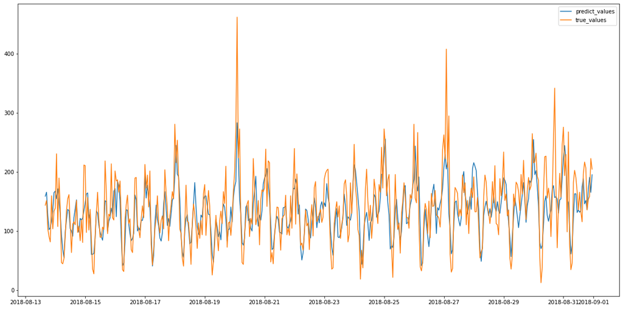

```python
plt.figure(figsize=(20,10))
plt.plot(predictions, label='predict_values')
plt.plot(target_test, label='true_values')
plt.legend();
```

На данном графике можем увидеть, что модель неплохо предсказывает количество заказов в обычных условиях, однако во время пикового спроса на услуги такси модель не очень хорошо справляется с предсказанием количества заказов, несколько занижая количество предсказанных поездок.

Тем не менее CatBoost обеспечивает приемлемую точность предсказания, установленную условиями проекта: RMSE CatBoost на тестовой выборке - 39.35 при требуемом уровне не более 48.

Проверим модель на адекватность. Для этого сравним её с константной моделью. Для задач регрессии константная модель предсказывает медианное значение количества заказов. При этом медиану будем считать на тренировочной выборке, имитируя процесс обучения.

```python
predictions_median = pd.Series(target_train.median(), index=target_test.index)
print('RMSE на отложенной выборке для константной модели:', round(mse(target_test, predictions_median, squared=False), 6))
```

```
RMSE на отложенной выборке для константной модели: 87.210938
```

Посмотрим на качество модели, которая будет предсказывать предыдущее значение ряда.

Для этого сместим временной ряд из тестовой выборки на 1 шаг, а 1 его значение, которое станет пропущенным, заменим на последнее значение ряда из тренировочной выборки.

```python
predictions_shift = target_test.shift()
predictions_shift.iloc[0] = target_train.iloc[-1]
```

Посчитаем RMSE.

```python
print('RMSE на отложенной выборке для наивной модели:', round(mse(target_test, predictions_shift, squared=False), 6))
```

```
RMSE на отложенной выборке для наивной модели: 58.881777
```

Видим, что наша модель CatBoost предсказывает количество поездок существенно лучше константной и наивной модели, из чего делаем вывод, что построенная модель является адекватной.

Таким образом, компании "Чётенькое такси" можно рекомендовать использовать CatBoost для предсказания количества поездок.

# Вывод по этапу 3.

На данном этапе мы протестировали модели LinearRegression, CatBoost, LightGBM и RandomForest: для моделей (кроме моделей LinearRegression и CatBoost) были подобраны оптимальные гиперпараметры с помощью алгоритма GridSearchCV, качество моделей было оценено на тестовой выборке с помощью метрики RMSE.

Результаты:

1. LinearRegression: RMSE = 45.47 заказа;
2. CatBoost: RMSE = 39.35 заказов;
3. LightGBM: RMSE = 41.30 заказов;
4. RandomForest: RMSE = 43.67 заказов.

Модель CatBoost смогла обеспечить наивысший уровень точности предсказания количества заказов среди протестированных моделей. Данная модель была сравнена с константной и наивной моделями и прошла проверку на адекватность. При анализе разницы между реальными значениями временного ряда из тестовой выборки и предсказанными моделью значениями было выявлено, что модель неплохо предсказывает количество поездок в нормальное время, однако в пиковые часы предсказывает количество поездок недостаточно точно, несколько занижая их количество.

# Итоговый вывод по проекту.

Компания «Чётенькое такси» собрала исторические данные о заказах такси в аэропортах. Чтобы привлекать больше водителей в период пиковой нагрузки, нужно спрогнозировать количество заказов такси на следующий час. Постройте модель для такого предсказания.

Значение метрики *RMSE* на тестовой выборке должно быть не больше 48.

Проект выполнялся в следующем порядке:

1. Импорт библиотек, считывание и первичный анализ данных.
2. Анализ данных, подготовка новых признаков.
3. Обучение и тестирование моделей, подбор гиперпараметров.

Отметим основные выводы.

# Вывод по этапу 1.

На данном этапе были импортированы необходимые библиотеки, а также считан и проанализирован первичный набор данных.

Набор данных представляет собой временной ряд, который описывает количество заказов такси с 2018-03-01 по 2018-08-31 с десятиминутным интервалом.

Пропущенные и аномальные значения, а также дубликаты не выявлены.

# Вывод по этапу 2.

На данном этапе мы проанализировали временной ряд и создали новые признаки.

Была осуществлена проверка упорядоченности индексов (дат) по возрастанию, визуализирован временной ряд, применена техника скользящего среднего с размером окна от 1 до 25 для сглаживания временного ряда, разложение временного ряда на компоненты (тренд, сезон, ошибка), а также сгенерированы новые признаки: год, месяц, день и день недели на дату измерения количества заказов, значения количества заказов при сдвиге на величину лага, а также скользящее среднее и скользящее стандартное отклонение временного ряда.

В ходе анализа удалось отметить, что временной ряд демонстрирует явную тенденцию к увеличению количества заказов, имея при этом суточную сезонность: пиковое время, когда заказов больше всего - промежуток с 6 утра до 10-11 утра и с 6 вечера до 1-2 ночи. Напротив, наименее продуктивным временем считается промежуток с 2 часов ночи до 6 часов утра.

# Вывод по этапу 3.

На данном этапе мы протестировали модели LinearRegression, CatBoost, LightGBM и RandomForest: для моделей (кроме моделей LinearRegression и CatBoost) были подобраны оптимальные гиперпараметры с помощью алгоритма GridSearchCV, качество моделей было оценено на тестовой выборке с помощью метрики RMSE.

Результаты:

1. LinearRegression: RMSE = 45.47 заказа;
2. CatBoost: RMSE = 39.35 заказов;
3. LightGBM: RMSE = 41.30 заказов;
4. RandomForest: RMSE = 43.67 заказов.

Модель CatBoost смогла обеспечить наивысший уровень точности предсказания количества заказов среди протестированных моделей. Данная модель была сравнена с константной и наивной моделями и прошла проверку на адекватность. При анализе разницы между реальными значениями временного ряда из тестовой выборки и предсказанными моделью значениями было выявлено, что модель неплохо предсказывает количество поездок в нормальное время, однако в пиковые часы предсказывает количество поездок недостаточно точно, несколько занижая их количество.